# WeRateDogs Twitter Data Wrangling

### 3. Define

Rename columns

#### 3. Code

```python
df_clean = df_clean.rename(columns = {'source': 'tweet_source',
                                        'expanded_urls': 'tweet_url', 'timestamp': 'tweet_date'})
```

#### 3. Test

```python
df_clean.head()
```

|  | tweet_id | in_reply_to_status_id | in_reply_to_user_id | tweet_date | tweet_source | text | retweeted_status_id | retweeted_status_user_id | retweeted_status_timestamp | tweet_url | rating_numerator | rating_denominator | name | doggo | floofer | pupper | puppo | date |
| --- | --- | --- | --- | --- | --- | --- | --- | --- | --- | --- | --- | --- | --- | --- | --- | --- | --- | --- |
| 0 | 892420643555336193 | NaN | NaN | 2017-08-01 16:23:56+00:00 | <a href="http://twitter.com/download/iphone" r... | This is Phineas. He's a mystical boy. Only eve... | NaN | NaN | NaN | https://twitter.com/dog_rates/status/892420643... | 13 | 10 | Phineas | None | None | None | None | 08.01.2017 |
| 1 | 892177421306343426 | NaN | NaN | 2017-08-01 00:17:27+00:00 | <a href="http://twitter.com/download/iphone" r... | This is Tilly. She's just checking pup on you.... | NaN | NaN | NaN | https://twitter.com/dog_rates/status/892177421... | 13 | 10 | Tilly | None | None | None | None | 08.01.2017 |
| 2 | 891815181378084864 | NaN | NaN | 2017-07-31 00:18:03+00:00 | <a href="http://twitter.com/download/iphone" r... | This is Archie. He is a rare Norwegian Pouncin... | NaN | NaN | NaN | https://twitter.com/dog_rates/status/891815181... | 12 | 10 | Archie | None | None | None | None | 07.31.2017 |
| 3 | 891689557279858688 | NaN | NaN | 2017-07-30 15:58:51+00:00 | <a href="http://twitter.com/download/iphone" r... | This is Darla. She commenced a snooze mid meal... | NaN | NaN | NaN | https://twitter.com/dog_rates/status/891689557... | 13 | 10 | Darla | None | None | None | None | 07.30.2017 |
| 4 | 891327558926688256 | NaN | NaN | 2017-07-29 16:00:24+00:00 | <a href="http://twitter.com/download/iphone" r... | This is Franklin. He would like you to stop ca... | NaN | NaN | NaN | https://twitter.com/dog_rates/status/891327558... | 12 | 10 | Franklin | None | None | None | None | 07.29.2017 |

### 4. Define

Delete unnecessary columns from df\

#### 4. Code and Test

```python
df_clean.drop(['retweeted_status_user_id', 'retweeted_status_timestamp','in_reply_to_status_id', 'in_reply_to_user_id','retweeted_status_id'], axis=1, inplace=True)
df_clean.head()
```

|  | tweet_id | tweet_date | tweet_source | text | tweet_url | rating_numerator | rating_denominator | name | doggo | floofer | pupper | puppo | date |
| --- | --- | --- | --- | --- | --- | --- | --- | --- | --- | --- | --- | --- | --- |
| 0 | 892420643555336193 | 2017-08-01 16:23:56+00:00 | <a href="http://twitter.com/download/iphone" r... | This is Phineas. He's a mystical boy. Only eve... | https://twitter.com/dog_rates/status/892420643... | 13 | 10 | Phineas | None | None | None | None | 08.01.2017 |
| 1 | 892177421306343426 | 2017-08-01 00:17:27+00:00 | <a href="http://twitter.com/download/iphone" r... | This is Tilly. She's just checking pup on you.... | https://twitter.com/dog_rates/status/892177421... | 13 | 10 | Tilly | None | None | None | None | 08.01.2017 |
| 2 | 891815181378084864 | 2017-07-31 00:18:03+00:00 | <a href="http://twitter.com/download/iphone" r... | This is Archie. He is a rare Norwegian Pouncin... | https://twitter.com/dog_rates/status/891815181... | 12 | 10 | Archie | None | None | None | None | 07.31.2017 |
| 3 | 891689557279858688 | 2017-07-30 15:58:51+00:00 | <a href="http://twitter.com/download/iphone" r... | This is Darla. She commenced a snooze mid meal... | https://twitter.com/dog_rates/status/891689557... | 13 | 10 | Darla | None | None | None | None | 07.30.2017 |
| 4 | 891327558926688256 | 2017-07-29 16:00:24+00:00 | <a href="http://twitter.com/download/iphone" r... | This is Franklin. He would like you to stop ca... | https://twitter.com/dog_rates/status/891327558... | 12 | 10 | Franklin | None | None | None | None | 07.29.2017 |

### 5. Define

Replace wrong names from names into NaN

#### 5. Code and Test

```python
# replace the stopwords into nan
df_clean.name.value_counts()
```

```
None          686
a              55
Charlie        12
Cooper         11
Lucy           11
             ...
Dex             1
Ace             1
Tayzie          1
Grizzie         1
Christoper      1
Name: name, Length: 957, dtype: int64
```

```python
# replace into nan
mask1 = df_clean.name == 'a'
df_clean.loc[mask1, 'name'] = 'None'
mask = df_clean.name == 'None'
mask1 = df_clean[mask].text.str.contains('named')
list(df_clean[mask & mask1].text)[:3]
extracted_names = df_clean[mask & mask1].text.str.extract(r'(named [A-Za-z]+)')
df_clean.loc[extracted_names.index, 'name'] = extracted_names[0].str.lstrip('named ')

# test
df_clean.name.value_counts()
```

```
None          718
Charlie        12
Lucy           11
Cooper         11
Oliver         11
             ...
Storkson        1
Remy            1
Chadrick        1
Kellogg         1
Christoper      1
Name: name, Length: 974, dtype: int64
```

### 6. Define

Dropout rows with P1_confidence less than coefficient 0.5 in image_prediction

#### 6. Code and Test

```python
df_pred = df_pred[df_pred['p1_conf'] > 0.5 ]
assert [df_pred[df_pred['p1_conf'] > 0.5 ]]
df_pred[['p1_conf']].sample(5)
```

|  | p1_conf |
| --- | --- |
| 1959 | 0.673664 |
| 1739 | 0.960199 |
| 611 | 0.999365 |
| 1010 | 0.797450 |
| 536 | 0.752707 |

### 7. Define

p1, p2 and p3 in df_pred has uppercase and lowcase ans should be Uppercase

#### 7. Code and Test

```python
# p1, p2 and p3 in df_pred has uppercase and lowcase ans should be Uppercase
```

```python
df_pred.p1 = df_pred.p1.apply(lambda x: x.title())
df_pred.p2 = df_pred.p1.apply(lambda x: x.title())
df_pred.p3 = df_pred.p1.apply(lambda x: x.title())

# test
df_pred[['p1','p2','p3']].sample(10)
```

|  | p1 | p2 | p3 |
| --- | --- | --- | --- |
| 1717 | Prison | Prison | Prison |
| 1335 | Bookshop | Bookshop | Bookshop |
| 1248 | Pembroke | Pembroke | Pembroke |
| 1484 | Tennis_Ball | Tennis_Ball | Tennis_Ball |
| 1941 | German_Shepherd | German_Shepherd | German_Shepherd |
| 1008 | Chihuahua | Chihuahua | Chihuahua |
| 417 | Pomeranian | Pomeranian | Pomeranian |
| 586 | Panpipe | Panpipe | Panpipe |
| 270 | Web_Site | Web_Site | Web_Site |
| 398 | Samoyed | Samoyed | Samoyed |

```python
# drop p2, p3

df_pred.drop(['p2', 'p3'], axis=1, inplace=True)

# rename p1 in breed

df_pred = df_pred.rename(columns = {'p1': 'breed'})
df_pred.head()
```

|  | tweet_id | jpg_url | img_num | breed | p1_conf | p1_dog | p2_conf | p2_dog | p3_conf | p3_dog |
| --- | --- | --- | --- | --- | --- | --- | --- | --- | --- | --- |
| 1 | 666029285002620928 | https://pbs.twimg.com/media/CT42GRgUYAA5iDo.jpg | 1 | Redbone | 0.506826 | True | 0.074192 | True | 0.072010 | True |
| 2 | 666033412701032449 | https://pbs.twimg.com/media/CT4521TWwAEvMyu.jpg | 1 | German_Shepherd | 0.596461 | True | 0.138584 | True | 0.116197 | True |
| 4 | 666049248165822465 | https://pbs.twimg.com/media/CT5IQmsXIAAKY4A.jpg | 1 | Miniature_Pinscher | 0.560311 | True | 0.243682 | True | 0.154629 | True |
| 5 | 666050758794694657 | https://pbs.twimg.com/media/CT5Jof1WUAEuVxN.jpg | 1 | Bernese_Mountain_Dog | 0.651137 | True | 0.263788 | True | 0.016199 | True |
| 6 | 666051853826850816 | https://pbs.twimg.com/media/CT5KoJ1WoAAJash.jpg | 1 | Box_Turtle | 0.933012 | False | 0.045885 | False | 0.017885 | False |

### 8. Define

Convert the null values to None type in dogs name

#### 8. Code and Test

```python
#Convert the null values to None type
df_clean.loc[df_clean['name'] == 'NaN', 'name'] = None
df_clean.loc[df_clean['name'] == 'an', 'name'] = None
df_clean.loc[df_clean['name'] == 'the', 'name'] = None
df_clean.loc[df_clean['name'] == 'a', 'name'] = None
#test
df_clean['name'].sample(10)
```

```
1838        None
662        Misty
2150       Kloey
1520    Vinscent
126       Cooper
129       Shikha
2242        None
1596        None
1058        None
1571     Blakely
Name: name, dtype: object
```

### 9. Define

Merge all tables in one

#### 9. Code and Test

```python
# first change tweet id columns to object datatype (in the other tables)
final_json = tweet_json[['id', 'retweet_count', 'favorite_count']]


final_json = final_json.astype({'id': 'object'})
df_pred = df_pred.astype({'tweet_id': 'object'})

# for consistency, change 'id' in json_data_df to 'tweet_id'
final_json.rename(columns = {'id':'tweet_id'}, inplace = True)
final = pd.merge(df_pred,final_json,on='tweet_id')

final.head()
```

|  | tweet_id | jpg_url | img_num | breed | p1_conf | p1_dog | p2_conf | p2_dog | p3_conf | p3_dog | retweet_count | favorite_count |
| --- | --- | --- | --- | --- | --- | --- | --- | --- | --- | --- | --- | --- |
| 0 | 666029285002620928 | https://pbs.twimg.com/media/CT42GRgUYAA5iDo.jpg | 1 | Redbone | 0.506826 | True | 0.074192 | True | 0.072010 | True | 48 | 132 |
| 1 | 666033412701032449 | https://pbs.twimg.com/media/CT4521TWwAEvMyu.jpg | 1 | German_Shepherd | 0.596461 | True | 0.138584 | True | 0.116197 | True | 47 | 128 |
| 2 | 666049248165822465 | https://pbs.twimg.com/media/CT5IQmsXIAAKY4A.jpg | 1 | Miniature_Pinscher | 0.560311 | True | 0.243682 | True | 0.154629 | True | 41 | 111 |
| 3 | 666050758794694657 | https://pbs.twimg.com/media/CT5Jof1WUAEuVxN.jpg | 1 | Bernese_Mountain_Dog | 0.651137 | True | 0.263788 | True | 0.016199 | True | 60 | 136 |
| 4 | 666051853826850816 | https://pbs.twimg.com/media/CT5KoJ1WoAAJash.jpg | 1 | Box_Turtle | 0.933012 | False | 0.045885 | False | 0.017885 | False | 879 | 1253 |

## Tidiness

### 1. Define

Check for the duplicated values and delete useless data

#### 1. Code and Test

```python
#df_clean =  pd.merge(df_clean, df_pred['p1_dog', 'jpg_url','p1','p1_dog'],  how ='inner', on='tweet_id')
# Print the count of the unique elements in all columns
final.apply(lambda x: len(x.unique()))
```

```
tweet_id          1238
jpg_url           1196
img_num              4
breed              249
p1_conf           1194
p1_dog               2
p2_conf           1195
p2_dog               2
p3_conf           1196
p3_dog               2
retweet_count     1065
favorite_count    1135
dtype: int64
```

### 2. Define

Create one table "tweet_rating" from rating_numerator and rating_denominator

#### 2. Code and Test

```python
df_clean['tweet_rating'] = np.divide(df_clean.rating_numerator,df_clean.rating_denominator)
print(df_clean['tweet_rating'].sample(10))
```

```
232     1.0
2116    0.9
1248    1.1
393     1.1
1152    1.1
341     1.3
2278    1.2
1713    1.0
1356    0.9
1275    1.3
Name: tweet_rating, dtype: float64
```

### 3. Define

#### 3. Code and Test

```python
print(df.doggo.value_counts())
print(df.floofer.value_counts())
print(df.pupper.value_counts())
print(df.puppo.value_counts())
```

```
None     2259
doggo      97
Name: doggo, dtype: int64
None       2346
floofer      10
Name: floofer, dtype: int64
None      2099
pupper     257
Name: pupper, dtype: int64
None     2326
puppo      30
Name: puppo, dtype: int64
```

```python
# create another column for tweets that is not one of four stages
cover = ((df_clean['doggo'] == 'None') & (df_clean['floofer'] == 'None')
        & (df_clean['pupper'] == 'None') & (df_clean['puppo'] == 'None'))

# we will make 5 values: 'doggo', 'floofer', 'pupper', 'puppo' and 'not_specified'
# for dogs without any kind.
df_clean['not_specified'] = np.where(cover, 'not_specified', 'None')
merge = set(['doggo', 'floofer', 'pupper', 'puppo', 'not_specified'])

df_clean = df_clean.melt(id_vars= set(df_clean.columns).difference(merge),
                          value_vars= merge,
                          var_name='dog_kind',
                          value_name='value')
# remove extra rows an column
cover = df_clean['dog_kind'] == df_clean['value']
df_clean = df_clean[cover]
df_clean.drop(columns='value', inplace=True)
# test
df_clean.sample(4)
```

|  | tweet_rating | tweet_id | date | name | rating_numerator | rating_denominator | tweet_source | tweet_date | text | tweet_url | dog_kind |
| --- | --- | --- | --- | --- | --- | --- | --- | --- | --- | --- | --- |
| 7766 | 1.0 | 757741869644341248 | 07.26.2016 | Leonard | 10 | 10 | <a href="http://twitter.com/download/iphone" r... | 2016-07-26 00:58:34+00:00 | This is Leonard. He hides in bushes to escape ... | https://twitter.com/dog_rates/status/757741869... | not_specified |
| 1268 | 1.1 | 707411934438625280 | 03.09.2016 | None | 11 | 10 | <a href="http://twitter.com/download/iphone" r... | 2016-03-09 03:45:22+00:00 | "I shall trip the big pupper with leash. Big p... | https://twitter.com/dog_rates/status/707411934... | pupper |
| 9157 | 1.0 | 666418789513326592 | 11.17.2015 | Walter | 10 | 10 | <a href="http://twitter.com/download/iphone" r... | 2015-11-17 00:53:15+00:00 | This is Walter. He is an Alaskan Terrapin. Lov... | https://twitter.com/dog_rates/status/666418789... | not_specified |
| 8364 | 1.2 | 690989312272396288 | 01.23.2016 | None | 12 | 10 | <a href="http://vine.co" rel="nofollow">Vine -... | 2016-01-23 20:07:44+00:00 | We've got a doggy down. Requesting backup. 12/... | https://vine.co/v/iOZKZEU2nHq | not_specified |

```python
# how specified pupper ,doggo ,puppo ,floofer
df_clean.dog_kind.value_counts()
```

```
not_specified    1923
pupper            255
doggo              94
puppo              29
floofer            10
Name: dog_kind, dtype: int64
```

```python
df_pred.head()
```

|  | tweet_id | jpg_url | img_num | breed | p1_conf | p1_dog | p2_conf | p2_dog | p3_conf | p3_dog |
| --- | --- | --- | --- | --- | --- | --- | --- | --- | --- | --- |
| 1 | 666029285002620928 | https://pbs.twimg.com/media/CT42GRgUYAA5iDo.jpg | 1 | Redbone | 0.506826 | True | 0.074192 | True | 0.072010 | True |
| 2 | 666033412701032449 | https://pbs.twimg.com/media/CT4521TWwAEvMyu.jpg | 1 | German_Shepherd | 0.596461 | True | 0.138584 | True | 0.116197 | True |
| 4 | 666049248165822465 | https://pbs.twimg.com/media/CT5IQmsXIAAKY4A.jpg | 1 | Miniature_Pinscher | 0.560311 | True | 0.243682 | True | 0.154629 | True |
| 5 | 666050758794694657 | https://pbs.twimg.com/media/CT5Jof1WUAEuVxN.jpg | 1 | Bernese_Mountain_Dog | 0.651137 | True | 0.263788 | True | 0.016199 | True |
| 6 | 666051853826850816 | https://pbs.twimg.com/media/CT5KoJ1WoAAJash.jpg | 1 | Box_Turtle | 0.933012 | False | 0.045885 | False | 0.017885 | False |

### Define

Merge all tables after quality and tidiness improvements

#### Code and test

```python
final_1 = pd.merge(df_pred,df_clean,on='tweet_id')
final = pd.merge(final_1,final_json,on='tweet_id')
final.head()
```

|  | tweet_id | jpg_url | img_num | breed | p1_conf | p1_dog | p2_conf | p2_dog | p3_conf | p3_dog | ... | name | rating_numerator | rating_denominator | tweet_source | tweet_date | text | tweet_url | dog_kind | retweet_count | favorite_count |
| --- | --- | --- | --- | --- | --- | --- | --- | --- | --- | --- | --- | --- | --- | --- | --- | --- | --- | --- | --- | --- | --- |
| 0 | 666029285002620928 | https://pbs.twimg.com/media/CT42GRgUYAA5iDo.jpg | 1 | Redbone | 0.506826 | True | 0.074192 | True | 0.072010 | True | ... | None | 7 | 10 | <a href="http://twitter.com/download/iphone" r... | 2015-11-15 23:05:30+00:00 | This is a western brown Mitsubishi terrier. Up... | https://twitter.com/dog_rates/status/666029285... | not_specified | 48 | 132 |
| 1 | 666033412701032449 | https://pbs.twimg.com/media/CT4521TWwAEvMyu.jpg | 1 | German_Shepherd | 0.596461 | True | 0.138584 | True | 0.116197 | True | ... | None | 9 | 10 | <a href="http://twitter.com/download/iphone" r... | 2015-11-15 23:21:54+00:00 | Here is a very happy pup. Big fan of well-main... | https://twitter.com/dog_rates/status/666033412... | not_specified | 47 | 128 |
| 2 | 666049248165822465 | https://pbs.twimg.com/media/CT5IQmsXIAAKY4A.jpg | 1 | Miniature_Pinscher | 0.560311 | True | 0.243682 | True | 0.154629 | True | ... | None | 5 | 10 | <a href="http://twitter.com/download/iphone" r... | 2015-11-16 00:24:50+00:00 | Here we have a 1949 1st generation vulpix. Enj... | https://twitter.com/dog_rates/status/666049248... | not_specified | 41 | 111 |
| 3 | 666050758794694657 | https://pbs.twimg.com/media/CT5Jof1WUAEuVxN.jpg | 1 | Bernese_Mountain_Dog | 0.651137 | True | 0.263788 | True | 0.016199 | True | ... | None | 10 | 10 | <a href="http://twitter.com/download/iphone" r... | 2015-11-16 00:30:50+00:00 | This is a truly beautiful English Wilson Staff... | https://twitter.com/dog_rates/status/666050758... | not_specified | 60 | 136 |
| 4 | 666051853826850816 | https://pbs.twimg.com/media/CT5KoJ1WoAAJash.jpg | 1 | Box_Turtle | 0.933012 | False | 0.045885 | False | 0.017885 | False | ... | None | 2 | 10 | <a href="http://twitter.com/download/iphone" r... | 2015-11-16 00:35:11+00:00 | This is an odd dog. Hard on the outside but lo... | https://twitter.com/dog_rates/status/666051853... | not_specified | 879 | 1253 |

5 rows × 22 columns

```python
# Saving df as csv
final.to_csv('twitter_archive_master.csv')
```

# Analyzing and Visualizing

At least three (3) insights and one (1) visualization must be produced

Questions:

1. Which dog kinds is most often, favorite ?
2. Which words in text is more frequent?
3. What is most rated dog breeeds?
4. What is most popular dogs names?

```python
# importing the data
df_archive = pd.read_csv('twitter_archive_master.csv')
df_breed = df_archive.copy()
```

### 1. Which dog kinds is most often, favorite ?

```
(0.0, 4.2)
```

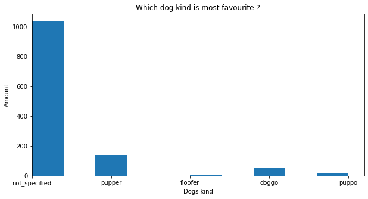

```python
# histogram
#df_breed = df_breed[df_breed.dog_kind != 'not_specified']

plt.figure(figsize=(10,5))
plt.xlabel('Dogs kind')
plt.ylabel('Amount')
plt.title('Which dog kind is most favourite ?')
plt.hist(data = df_breed, x='dog_kind');
plt.xlim(0)
```

Most dogs are not_specified - 1035, pupper -140, doggo - 52, puppo - 19 and floofer just 3.

### 2. Which dog breed are most rated?

```python
df_breed.breed.value_counts()
```

```
Golden_Retriever       131
Pembroke                70
Labrador_Retriever      70
Chihuahua               50
Pug                     45
                      ...
Guenon                   1
Black-Footed_Ferret      1
Rain_Barrel              1
Bubble                   1
Convertible              1
Name: breed, Length: 249, dtype: int64
```

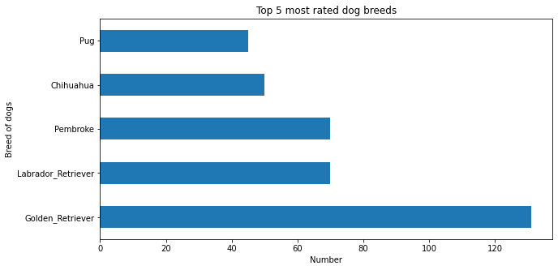

```python
dog_breed = df_breed.groupby('breed').filter(lambda x: len(x) >= 33)
plt.figure(figsize=(10,5))
dog_breed['breed'].value_counts().plot(kind = 'barh')
plt.title('Top 5 most rated dog breeds')
plt.xlabel('Number')
plt.ylabel('Breed of dogs')
```

### 3. Which words in text is more frequent?

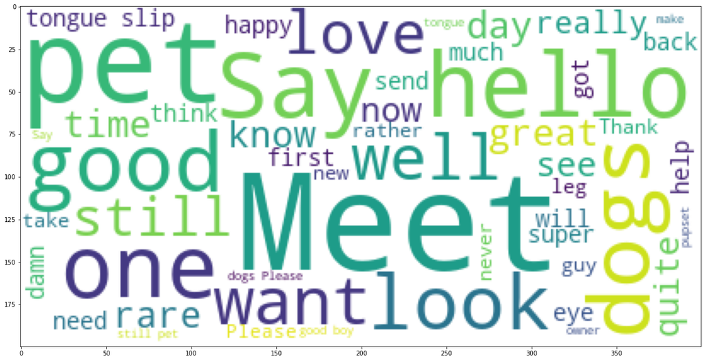

```python
tweets_text = "".join(text + ", " for text in df_breed.text)
stopword = set(STOPWORDS)
stopword.update(['t','dog','dog_rates','goggo','doggo', 'h', 'co', 'af','amp','tho','ck','RT','ear','amp','tho', 'ckin', 'rate', 'https', 'floofer','floof','pupper','pupp', 'pup'])
my_cloud = WordCloud(min_font_size=6, max_font_size=80, max_words=50,
                     stopwords= stopword, background_color ='white').generate(tweets_text)
plt.figure(figsize=[20,15])

plt.imshow(my_cloud)
```

### 4. Which dog names most popular?

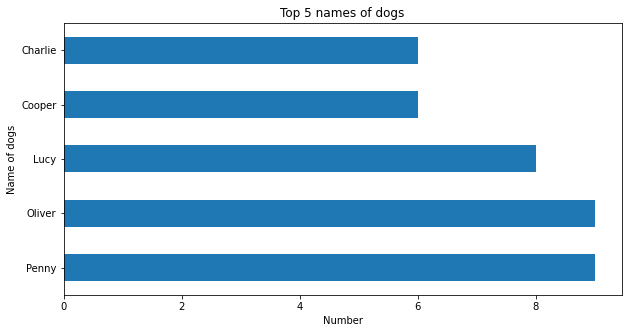

```python
dog_breed = df_breed[df_breed!= "None"]
dog_breed_2 = dog_breed.groupby('name').filter(lambda x: len(x) >= 6)
plt.figure(figsize=(10,5))
dog_breed_2['name'].value_counts().plot(kind = 'barh')
plt.title('Top 5 names of dogs')
plt.xlabel('Number')
plt.ylabel('Name of dogs')
```

#### Insight 3:

Top 5 dogs name: 1. Penny, 2.Oliver,3.Lucy, 4.Cooper, 5.Charlie